# Writeup for submission of Course Project

VG

Sunday, April 26, 2015

## Load and examine the training data

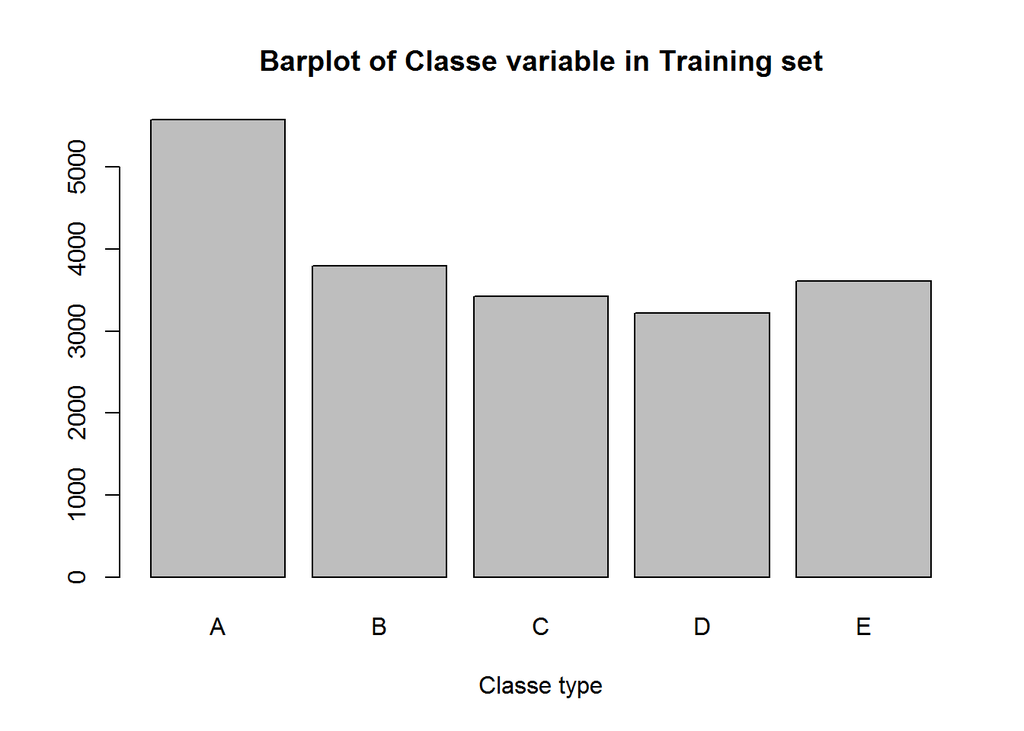

## Load and examine the test data

- There are 20 observations for testing.
- The predictor variables are the same.
- There are factor variables.
- 100 of the predictor variables in the test set have all missing values, i.e., these variables have no predictive power. Therefore, we will exclude these variables from the training set in order to speed up the model. The number of predictors to be used goes down to 59.

## Partition the training data

- Partition the training data into a *train* and *test* sets — we will train the model on the *train* set and test it on the *test* set.
- We will use the *createDataPartition* command from the CARET package, which ensures a stratified sample with representative levels of response variable (a factor).
- 75% of the training data will be assigned to the *train* set and the remainder to the *test* set.
- We will use a Random Forest model (which as shown below performs very well) using the Random Forest package (which is much faster than the CARET package).
- Per [link] (http://www.stat.berkeley.edu/~breiman/RandomForests/cc_home.htm#ooberr): “In random forests, there is no need for cross-validation or a separate test set to get an unbiased estimate of the test set error.” Therefore, we will not set aside a cross validation set.

## Run exploratory Random Forest model

- We will use the default number of trees in the Random Forest package plus 1 to avoid ties (ntree=501)

```r
#library(randomForest)
#modelFitRFexpl <- randomForest(classe ~ ., data = train, ntree=501, na.rm=TRUE)
#print(modelFitRFexpl)
#print(order(importance(modelFitRFexpl, type=2), decreasing=TRUE))
```

- The OOB estimate of the error rate is 0%, which suggests overfitting.
- When looking at the order of variable importance, we can see that the following variables are at the top of the list and they seem to be unique identifiers of each row and hence, each response variable:
- “X”
- “cvtd_timestamp”
- “raw_timestamp_part_1”
- “roll_belt”
- We remove the first three of these predictors from the training data to avoid overfitting.

## Refit the Random Forest model excluding the three predictors above

- The OOB estimate of the error rate is now 0.46%, i.e., the expected number of misclassified observations on a test set of 4904 observations is approximately 23 misclassified cases.

## Test the model using the *test* data set aside by the partition command

```r
#pred.FitRF <- predict(modelFitRF, test[ ,-c(60)], type="response")
#table(observed = test$classe, predicted = pred.FitRF)
```

- There are 22 misclassified cases out of 4904 observations, which closely mirrors the OOB estimate of the error rate (the latter is shown to be unbiased in a lot of situations).

## The model above achieved 100% accuracy when run against the sample data points in Part 2 of the assignment.